# Reading Files

Haley Jeppson, Joe Papio, Sam Tyner

June 14, 2017

# Data in Excel

- Formats xls and csv - what’s the difference?
- File extensions xls and xlsx are proprietary Excel formats, binary files
- csv is an extension for Comma Separated Value files. They are text files - directly readable.
- Example: Gas prices in midwest since 1994

# Gas Prices in the Midwest

```r
midwest <- read.csv("http://heike.github.io/rwrks/03-r-format/data/midwest.csv")
head(midwest)
```

```
##   Year.Month   Week.1     X   Week.2   X.1   Week.3   X.2   Week.4   X.3
## 1            End Date Value End Date Value End Date Value End Date Value
## 2   1994-Nov                                                28-Nov 1.122
## 3   1994-Dec    5-Dec 1.086   12-Dec 1.057   19-Dec 1.039   26-Dec 1.027
## 4   1995-Jan    2-Jan 1.025    9-Jan 1.046   16-Jan 1.031   23-Jan 1.054
## 5   1995-Feb    6-Feb 1.045   13-Feb  1.04   20-Feb 1.031   27-Feb 1.052
## 6   1995-Mar    6-Mar 1.053   13-Mar 1.042   20-Mar 1.048   27-Mar 1.065
##     Week.5   X.4
## 1 End Date Value
## 2
## 3
## 4   30-Jan 1.055
## 5
## 6
```

# Gas Prices

```r
str(midwest)
```

```
## 'data.frame':    212 obs. of  11 variables:
##  $ Year.Month: Factor w/ 212 levels "","1994-Dec",..: 1 3 2 8 7 11 4 12 10 9 ...
##  $ Week.1    : Factor w/ 86 levels "","1-Apr","1-Aug",..: 86 1 52 18 65 69 26 10 56 31 ...
##  $ X         : Factor w/ 197 levels "","0.905","0.918",..: 197 1 19 7 12 13 21 29 42 31 ...
##  $ Week.2    : Factor w/ 86 levels "","10-Apr","10-Aug",..: 86 1 28 78 41 45 2 70 32 7 ...
##  $ X.1       : Factor w/ 206 levels "","0.919","0.921",..: 206 1 17 14 12 13 27 39 45 34 ...
##  $ Week.3    : Factor w/ 86 levels "","15-Apr","15-Aug",..: 86 1 52 18 65 69 26 10 56 31 ...
##  $ X.2       : Factor w/ 199 levels "","0.91","0.929",..: 199 1 11 9 9 15 28 40 38 29 ...
##  $ Week.4    : Factor w/ 85 levels "22-Apr","22-Aug",..: 85 82 51 17 64 68 25 9 55 30 ...
##  $ X.3       : Factor w/ 201 levels "0.883","0.921",..: 201 29 9 14 13 15 32 44 34 27 ...
##  $ Week.5    : Factor w/ 31 levels "","29-Apr","29-Aug",..: 31 1 1 16 1 1 1 9 1 27 ...
##  $ X.4       : Factor w/ 74 levels "","0.955","1.023",..: 74 1 1 5 1 1 1 18 1 11 ...
```

There is clearly some work to be done…

# `read.csv` vs. `read.table`

`read.csv` is really just a wrapper for `read.table` with certain parameters set:

```r
read.csv
```

```
## function (file, header = TRUE, sep = ",", quote = "\"", dec = ".",
##     fill = TRUE, comment.char = "", ...)
## read.table(file = file, header = header, sep = sep, quote = quote,
##     dec = dec, fill = fill, comment.char = comment.char, ...)
## <bytecode: 0xe900f0>
## <environment: namespace:utils>
```

So to properly read in this data, it’s probably best to use `read.table` directly

```r
?read.table
```

# Your Turn

Have a look at the parameters of read.table (?read.table) to solve the following problems:

1. Read the first two lines of the file into an object called `midwest_names`
2. Read everything EXCEPT the first two lines into an object called `midwest_data`

# Quick Lesson in Data Cleaning

```r
values <- c(midwest_data$V3, midwest_data$V5, midwest_data$V7,
            midwest_data$V9, midwest_data$V11)
dates <- c(paste(midwest_data$V1, midwest_data$V2, sep = "-"),
           paste(midwest_data$V1, midwest_data$V4, sep = "-"),
           paste(midwest_data$V1, midwest_data$V6, sep = "-"),
           paste(midwest_data$V1, midwest_data$V8, sep = "-"),
           paste(midwest_data$V1, midwest_data$V10, sep = "-"))

dates <- dates[!is.na(values)]
values <- values[!is.na(values)]

library(lubridate)
dates <- ymd(dates)

midwest_gas <- data.frame(date = dates, price = values)
midwest_gas <- midwest_gas[with(midwest_gas, order(date)), ]
```

# Now we can make a plot!

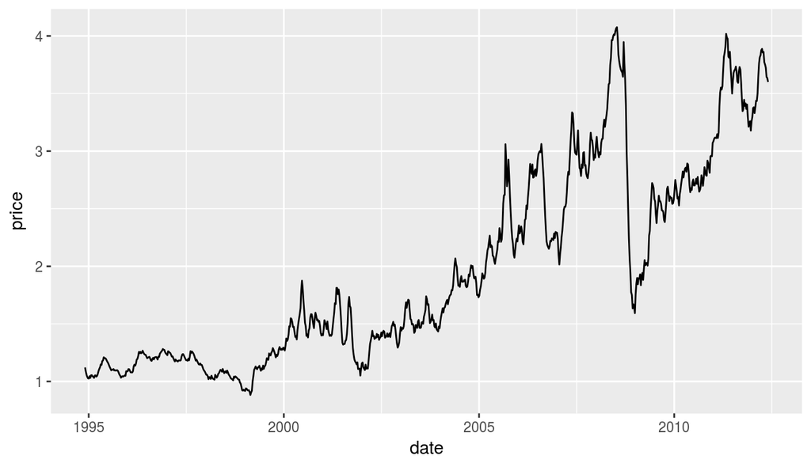

```r
library(ggplot2)
qplot(date, price, data = midwest_gas, geom = "line")
```

# Reading Excel Data

Download the midwest.xls file to your current working directory (`getwd()`)

[output not shown]

# `foreign` Package

- Other file formats can be read using the functions from package
- SPSS: `read.spss`
- SAS: `read.xport`
- Minitab: `read.mtp`
- Systat: `read.systat`

# Your Turn (~2 minutes)

The NHANES (National Health and Nutrition Survey) publishes data in the SAS xport format:

http://wwwn.cdc.gov/Nchs/Nhanes/Search/nhanes13_14.aspx

1. Scroll to the bottom, choose one of the datasets (Demographics, Examination, etc.). Download the Data file (XPT)
2. Use `read.xport()` to load the file into R
3. Briefly examine the dataset you’ve imported (use `head` or `tail`, etc)